# Herbivores reduce seedling recruitment in alpine plant communities - Opedal - 2021 - Nordic Journal of Botany - Wiley Online Library

[Nordic Journal of Botany](https://onlinelibrary.wiley.com/journal/17561051)

[Volume 39, Issue 2](https://onlinelibrary.wiley.com/toc/17561051/2021/39/2)

Research Article

Open Access

# Herbivores reduce seedling recruitment in alpine plant communities

[Øystein H. Opedal](https://onlinelibrary.wiley.com/action/doSearch?ContribAuthorStored=Opedal%2C+%C3%98ystein+H)

[Kristin O. Nystuen](https://onlinelibrary.wiley.com/action/doSearch?ContribAuthorStored=Nystuen%2C+Kristin+O)

[Dagmar Hagen](https://onlinelibrary.wiley.com/action/doSearch?ContribAuthorStored=Hagen%2C+Dagmar)

[Håkon Holien](https://onlinelibrary.wiley.com/action/doSearch?ContribAuthorStored=Holien%2C+H%C3%A5kon)

[Mia Vedel Sørensen](https://onlinelibrary.wiley.com/action/doSearch?ContribAuthorStored=S%C3%B8rensen%2C+Mia+Vedel)

[Simone I. Lang](https://onlinelibrary.wiley.com/action/doSearch?ContribAuthorStored=Lang%2C+Simone+I)

[Sigrid Lindmo](https://onlinelibrary.wiley.com/action/doSearch?ContribAuthorStored=Lindmo%2C+Sigrid)

[G. Richard Strimbeck](https://onlinelibrary.wiley.com/action/doSearch?ContribAuthorStored=Strimbeck%2C+G+Richard)

[Bente J. Graae](https://onlinelibrary.wiley.com/action/doSearch?ContribAuthorStored=Graae%2C+Bente+J)

First published: 16 February 2021

https://doi.org/10.1111/njb.02989

## Abstract

Through changes in climate and other environmental factors, alpine tundra ecosystems are subject to increased cover of erect shrubs, reduced predictability of rodent dynamics and changes in wild and domesticated herbivore densities. To predict the dynamics of these ecosystems, we need to understand how these simultaneous changes affect alpine vegetation. In the long term, vegetation dynamics may depend critically on seedling recruitment. To study drivers of alpine plant seedling recruitment, we set up a field experiment where we manipulated the opportunity for plant–plant interactions through vegetation removal and introduction of willow transplants, the occurrence of herbivory through caging of plots, and then sowed 14 species into the plots. We replicated the experiment in three common alpine vegetation types (heath, meadow and *Salix* shrubland) and recorded seedling emergence and survival over five years. Strong effects of vegetation removal and substantial differences in recruitment among dominant vegetation types suggested important effects of local vegetation on the recruitment success of vascular‐plant seedlings. Similarly, herbivore exclusion had strong positive effects on recruitment success. This effect arose primarily via reduced seedling mortality in plots from which herbivores had been experimentally excluded and became noticeably stronger over time. In contrast, we detected no consistent effects of experimental willow shrub introduction on seedling recruitment. These results demonstrate that large and small herbivores can affect alpine plant seedling recruitment negatively by trampling and feeding on seedlings. Importantly, the effects became stronger over time, suggesting that effects of herbivory on seedling recruitment accumulates over time and may relate to recruitment phases beyond initial seedling emergence.

## Introduction

Arctic–alpine tundra ecosystems are thought to be disproportionally affected by ongoing environmental changes (Björk and Molau 2007, Vowles et al. 2017). Beyond direct effects of increasing temperatures on plant physiology, important indirect effects are expected to arise via changes in land use and in species interactions within and between trophic levels (Austrheim and Eriksson 2001, Körner 2003, Olofsson et al. 2009, Vowles et al. 2017). One prominent example of expected changes in species interactions is the negative effects of ongoing shrub encroachment on many understorey plants (Pajunen et al. 2011, Mod and Luoto 2016, Wallace and Baltzer 2019). Increased shrub cover (‘shrubification') increases vegetation productivity and changes the nutrient and carbon dynamics of tundra heath and meadow vegetation (Sørensen et al. 2018a). Beyond these plant–plant interactions, it is also increasingly clear that patterns of vegetation change depend on interactions among trophic levels, notably herbivory (Olofsson et al. 2009, Kaarlejärvi et al. 2017). In alpine Fennoscandia, recent changes in herbivore communities include less predictable population cycles of small rodents (Kausrud et al. 2008, Framstad 2019, Ehrich et al. 2020), and changes in the abundance and composition of large wild and free‐ranging domestic herbivores (Austrheim et al. 2011, Speed et al. 2019). A better understanding of the direct and indirect effects of species interactions within and between trophic levels will be important for understanding the future dynamics of arctic–alpine ecosystems.

The vast majority of arctic–alpine plants are long‐lived and slow‐growing, and vegetation changes in these regions are therefore often slow (Billings 1987, Morris and Doak 1998, Körner 2003). Although clonal species can persist for long periods, long‐term vegetation dynamics depend increasingly on changes in community composition and hence successful seedling recruitment. Seedling recruitment is expected to depend on microclimatic conditions (Walck et al. 2011) and on species interactions (Fayolle et al. 2009, Milbau et al. 2013, Nystuen et al. 2019), both of which are likely to be affected by ongoing environmental changes. While seed production and germination in cold biomes are often found to respond positively to warmer temperatures, at least when sufficient soil moisture is available (Milbau et al. 2009, Klady et al. 2011, Walck et al. 2011), seedling survival and establishment are in turn thought to be sensitive to droughts associated with warm weather (Moles and Westoby 2004, Fenner and Thompson 2005, Leck et al. 2008). Predicting the net effect of environmental change on seedling recruitment is therefore complicated (Shevtsova et al. 2009).

Seedling recruitment may depend on plant–plant interactions, which are expected to differ among plant community types. For example, plant communities dominated by strong competitors, such as grasslands, are normally thought to be less invasible than are those dominated by ruderal species (Burke and Grime 1996, Lett et al. 2018a). The relative success of competitive species is likely to depend on the frequency of disturbances creating gaps in the vegetation, because gaps provide ‘safe sites' where competition is limited, thus allowing seedling recruitment (Grubb 1977, Graae et al. 2011, Milbau et al. 2013, Lembrechts et al. 2016). Therefore, if environmental changes affect the frequency of disturbances, this can change the invasibility of the vegetation and consequently lead to a shift in community composition.

The ongoing expansion of erect shrub communities in arctic–alpine regions (Myers‐Smith et al. 2011, Elmendorf et al. 2012, García Criado et al. 2020) may modify competitive interactions compared to those occurring in low‐growing vegetation types such as meadows and heaths. Previous work suggests that the net effect of erect shrub expansion on plant recruitment in tundra depends on the shrub species composition and extent of shrub cover, as well as the recruitment phase in question (Jumpponen et al. 1998, Dona and Galen 2007, Dufour‐Tremblay et al. 2012, Cranston and Hermanutz 2013). For example, shrubs trap snow and thereby create stable winter conditions known to benefit seedling survival for boreal species (Dona and Galen 2007, Lett et al. 2018b). However, light reduction is among the principal factors explaining low tree seedling occurrence (Jumpponen et al. 1998, Dufour‐Tremblay et al. 2012) and growth (Cranston and Hermanutz 2013) in tundra systems. Furthermore, shrubs may affect seedling recruitment through indirect effects, as when tall shrubs outcompete dwarf shrubs, graminoids or cryptogams (Pajunen et al. 2011), thereby allowing seedlings to recruit on the bare soil in the moist microclimate under the shrub canopy (Graae et al. 2011).

The fate of recruiting plants in shrub‐dominated vegetation may depend directly or indirectly on herbivory. For example, herbivory can affect the competitive capacity of the extant vegetation, and the frequency of vegetation gaps. Indeed, vegetation gaps are often associated with mammal activities such as burrowing and trampling (Watt and Gibson 1988, Ericson et al. 1992, Nystuen et al. 2014), and herbivory may therefore indirectly increase the invasibility of the vegetation (Eskelinen and Virtanen 2005, Olofsson 2006, Olsen and Klanderud 2014). However, small size and limited storage make seedlings highly vulnerable to trampling and herbivory. Herbivores can kill or reduce the performance of preferred species in arctic–alpine vegetation (Eskelinen 2008, Bognounou et al. 2018), although these effects may be weak compared to the positive effects of disturbances and consumption of extant vegetation (Eskelinen and Virtanen 2005). Compared to other ecosystems, seedlings in tundra are small and grow slowly, and are therefore of little interest to mammalian herbivores during their first years (Shaw et al. 2010). Therefore, herbivore‐induced seedling mortality may be less important in tundra compared to other community types (Hulme 1994, Hanley 1998, Clark et al. 2012). However, slow recovery of vegetation subject to trampling may increase the importance of herbivore‐induced disturbances.

To predict the joint outcome of shrub expansion and changes in herbivore pressure for the successional pathways in alpine vegetation we need a more mechanistic understanding of seedling recruitment processes. To this end, we sowed 14 species into plots in a full‐factorial plant recruitment experiment where we manipulated the opportunity for plant–plant interactions through vegetation removal and introduction of willow transplants, and the occurrence of herbivory through caging of plots. Because alpine terrains comprise a patchwork of distinct vegetation types, and invasibility is thought to differ among these, we replicated the experiment in three common alpine vegetation types: a meadow snowbed, a *Salix* shrubland and a dwarf‐shrub heath. If plant–plant interactions are important for seedling recruitment, we expect recruitment success to differ among vegetation types and between controls and experimentally encroached plots. We also expect that seedling emergence and establishment is greater when seeds are sown into experimental gaps in the extant vegetation. If herbivory is important, we expect greater mortality of emerged seedlings and consequently reduced establishment success in those plots exposed to natural herbivory.

## Material and methods

### Study sites

The study area is located in the low‐alpine vegetation zone around 1100 m a.s.l. near Hjerkinn, central Norway (Fig. 1A). The climate in the area is continental, with short warm summers and long cold winters (Moen 1998; Supporting information). We established study sites on three neighbouring mountain slopes representative of three common tundra vegetation types: a dwarf‐shrub‐dominated heath, an herb‐ and cryptogam‐dominated meadow, and a *Salix*‐dominated shrubland (Fig. 1A, Supporting information).

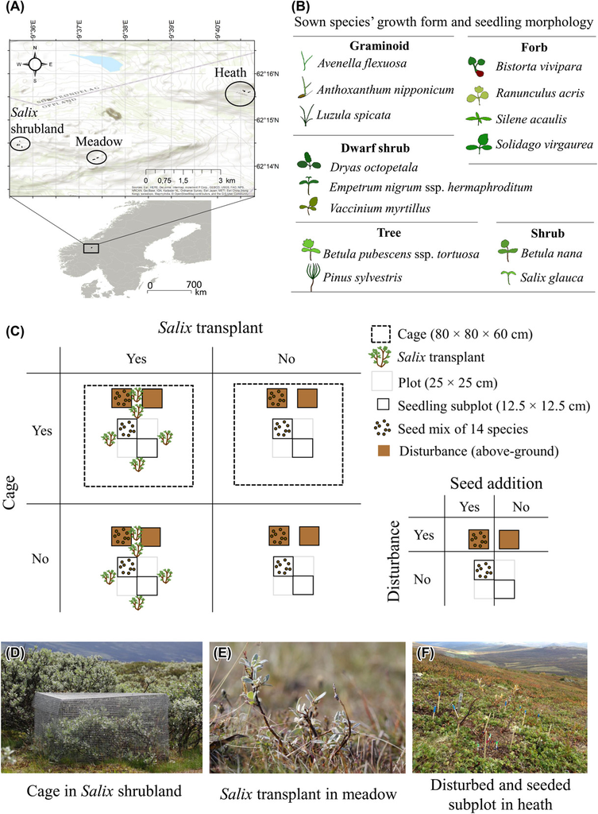

**Figure 1**

Graphical summary of the experiment. (A) Location of the study area and the three study sites near Hjerkinn, Dovrefjell, central Norway. (B) List of the 14 vascular plant species sown in the seeding experiment and their growth forms. (C) Schematic representation of the factorial experimental design with *Salix* transplants simulating shrub encroachment, cages excluding vertebrate herbivores, disturbance eliminating above‐ground competition from standing vegetation, and seed addition. Treatments were replicated eight times at each of the three sites. We recorded seedling emergence, survival and establishment over five years in the seedling subplots. Photos show the plant communities and treatments: (D) a cage at the *Salix* shrubland site, (E) a *Salix* transplant (ca 9 cm tall) at the meadow site two years after planting and (F) a disturbed and seeded subplot with plot and seedling markers at the heath site three years after sowing.

The study sites experience low‐intensity summer grazing and browsing by domestic sheep (NIBIO 2017). Wild herbivores present in the study area include voles (*Microtus agrestis*, *M. oeconomus* and *Myodes rufocanus*), lemmings *Lemmus lemmus*, hare *Lepus timidus*, ptarmigan (*Lagopus lagopus* and *L. muta*), moose *Alces alces* and the occasional passing of reindeer *Rangifer tarandus*. The small rodents exhibit cyclic population dynamics (Stenseth and Ims 1993) with population build‐ups in 2013 and 2017 resulting in moderate rodent peaks in 2014 and 2018 (Framstad 2019). The herbivores use the different vegetation types differently, with potential consequences for plant recruitment. Heaths are important resting sites for sheep, but are not preferred for grazing (Kausrud et al. 2006). Sheep grazing is more intense in the more productive meadow and shrub vegetation rich in herbaceous plants preferred by sheep (Kausrud et al. 2006). Seedlings in open plots are therefore exposed to sheep herbivory but may also experience reduced biotic competition as a result of grazing on the extant vegetation. Within dense shrub vegetation, understorey plants may be difficult to access and thereby escape large‐mammal herbivory (Pajunen et al. 2011), while smaller herbivores may benefit from shelter below shrub canopies. Winter herbivory by lemmings and voles is expected to be most important at the meadow and shrub sites, as rodents prefer habitats with a thick, insulating snow cover (Sætnan et al. 2009).

### Experimental setup and study design

In late June 2013 we placed 32 plots (25 × 25 cm) within the fairly homogenous vegetation at each site (see the Supporting information for further description of the study sites). The plots were assigned to a 2 × 2 factorial experiment comprising exclusion of herbivores with cages and planting of *Salix*, resulting in four treatment combinations with eight replicates per site (Fig. 1C). At each plot, we established four subplots (12.5 × 12.5 cm) for a 2 × 2 factorial experiment comprising disturbance and seed sowing. The two disturbed subplots were placed ca 15 cm outside the 25 × 25 cm plot to avoid interference with other ongoing experiments, while the two intact subplots were inside the 25 × 25 cm plot (Fig. 1C).

In the disturbed subplots, all aboveground vegetation was cut at soil surface to mimic a severe small‐scale disturbance event (Fig. 1C, F). In all seeded subplots, we sowed seeds from 14 plant species common in subalpine and low‐alpine vegetation (Fig. 1B). These species were chosen because they represent a variety of growth forms (tree, shrub, dwarf‐shrub, graminoid and forb) and seedling morphologies and have seeds (bulbils for *Bistorta vivipara*, hereafter referred to as seeds) and seedlings of different sizes which might affect their recruitment potential and resistance to herbivory and environmental stress. The species have easily distinguishable seedlings facilitating field identification. Seeds were collected in the study area when ripe during autumn 2013. The fleshy fruits of *Empetrum nigrum* ssp. *hermaphroditum* and *Vaccinium myrtillus* were kept in a refrigerator before they were gently squashed in a bowl of water to separate fruit flesh and seeds. The seeds were stored in paper bags at room temperature. *Pinus sylvestris* seeds were supplied by The Norwegian Forest Seed Center, collected at Oppdal ca 600–650 m a.s.l., about 40 km north of the study sites.

A mixture of 30 seeds per focal plant species was sown in each of the two seeded subplots in late autumn 2013 (Fig. 1B), except for *P. sylvestris* with only 10 seeds because of known high germination capacity (82%) and large seedling size, and *Salix glauca* with only 15 seeds due to limited seed availability. During sowing, a ca 20 cm tall cardboard frame was placed around the subplots to shelter from wind and avoid spilling of seeds (Eskelinen and Virtanen 2005). We sowed the *Betula nana* and *Betula pubescens* ssp. *tortuosa* seeds in spring 2014 because they matured after the other seeds were sown. To ensure that the *Betula* seeds experienced conditions similar to those of the already sown seeds, we kept them in paper bags under snow during winter (ca 8 km from the study site). Each seeded subplot received a total of 385 seeds with a seed density of 2.5 seeds per cm<sup>2</sup>. This density is higher than the expected natural seed rain in alpine vegetation (Molau and Larsson 2000, Graae et al. 2011). Because germination success in tundra is low (Graae et al. 2011), we increased the probability of successful seedling emergences by sowing many seeds. In each plot, one unseeded disturbed and one unseeded intact subplot served as controls for natural seedling emergence.

We recorded seedling emergence in all seeded and unseeded subplots in autumn 2014. Each seedling was determined to species and marked with a toothpick adjacent to the seedling. We drew a map of each subplot with seedling positions to ease identification in later years. The subplots were resurveyed for seedling survival and for newly emerged seedlings in July 2015 and in August 2016. The toothpicks were removed after the 2016 survey. In August 2018, we counted the number of seedlings still alive.

### Microenvironmental data

We recorded soil surface temperatures in intact vegetation and in the disturbed unseeded subplots, litter cover in all subplots and snow depth in all plots. Soil surface temperature (°C at ca 1 cm depth) was logged at four‐hour‐intervals with temperature sensors. Temperatures were logged in intact vegetation from autumn 2013 onwards, and in the disturbed unseeded subplots (representative of disturbed subplots in general) from summer 2016 onwards. We extracted absolute minimum and maximum temperatures and computed mean temperatures for summer (July and August) and winter (January and February). We estimated litter cover (%) visually for each subplot during the seedling censuses. We measured snow depth (cm) at four points per plot with avalanche probes in 2015 (14 March), 2016 (2 April), 2017 (11 March) and 2018 (19 April). If cages or marking sticks were not visible, we located the plots with the aid of a handheld GPS receiver (3 m precision).

### Hierarchical joint modelling of seedling emergence, mortality and establishment

We analysed the structure and dynamics of the seedling assemblages emerging in each seeded plot using Bayesian latent‐variable joint species distribution models (hierarchical modelling of species communities framework; Ovaskainen et al. 2017), implemented in the Hmsc 3.0 R package (Tikhonov et al. 2020). This approach allowed us to model the effects of the experimental treatments on the dynamics of all species jointly, while accounting for the non‐independence of seeds sown into the same plot.

Exploration of the data revealed a very strong effect of experimental disturbance on recruitment patterns. Thus, we chose to analyse the disturbed and intact subplots separately, focusing on the effects of the plot‐level experimental treatments (herbivore exclusion and willow introduction). To assess these treatment effects and whether they varied among sites and recruitment phases, we fitted four distinct models, separately for disturbed and intact subplots. In each model, we excluded very rare species occurring less than eight times in the response matrix (across all sites).

First, we modelled the effects of the plot‐level experimental treatments on seedling emergence in the first year following sowing (and vegetation removal for the disturbed subplots). We refer to seedling emergence as seed germination and seedling survival until census time. Treatment effects were allowed to vary among sites by including a treatment × site interaction. Environmental covariates included year‐specific mean and maximum summer temperatures, mean and minimum winter temperatures, snow cover and litter cover. The temperature variables were strongly correlated across years (Supporting information), which allowed us to replace a few missing values with the mean value (across years) for that plot.

Second, we modelled seedling survival rate between census years, including the number of seedlings in the focal plot in year *t* − 1 as an additional explanatory variable describing density‐dependent mortality.

Finally, we analysed the seedling assemblages of all sown species alive in the third and fifth year after sowing (2016 and 2018, respectively), which integrates both first‐year emergence, later emergence and survival. We refer to the assemblage of sown species in these later censuses, independently of their age class, as established seedlings.

All models were fitted with a probit link function, and we thus modelled rates of emergence, survival and establishment. We ran two independent MCMC chains of 30 000 iterations with the first 10 000 discarded as burnin, and a thinning interval of 20 iterations. We assessed model convergence qualitatively by investigation of posterior trace plots, and quantitatively by computing effective sample sizes and potential scale reduction factors (Supporting information). We computed the explanatory power of the model as the square correlation coefficient (r<sup>2</sup>) between the observed and predicted seedling abundances in each plot.

#### Interpreting the model results

Our Bayesian analytical approach is analogous to a more typical analysis of variance approach to analysing factorial experiments but differs in how statistical support is evaluated. To assess patterns of variation in seedling recruitment success across sites and treatments, we interpreted the model output as follows. First, we performed variance component analyses for each model, which allowed us to partition the explained variation (as given by the r<sup>2</sup>) into contributions of each fixed and random effect (latent variable). The variance components can be directly compared among models, and allow us to ask, for example, whether the distribution of variance within and among sites differ for the intact and disturbed subplots. While our focus is on interpreting effect sizes, we assessed statistical support for treatment effects within each site by computing posterior support values for the pairwise differences between treatments, i.e. the proportion of posterior samples for which pairwise differences were positive (for positive effects), or negative (for negative effects). Because the vegetation types were not replicated within our design, we do not test statistically for differences among vegetation types (i.e. sites).

## Results

### Seedling emergence

In intact vegetation, 596 seedlings emerged during the first growing‐season following sowing. Most of the variance in seedling emergence occurred among sites, while differences among the plot‐level experimental treatments were limited (Table 1). Neither herbivore exclusion nor willow introduction detectably affected the number of emerged seedlings at the meadow and shrubland sites. At the heath site, however, fewer seedlings tended to emerge in experimentally shrub‐encroached plots than in non‐encroached plots (Fig. 2).

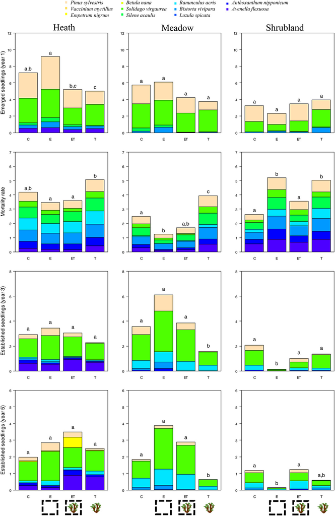

**Figure 2**

Effects of plot‐level experimental treatments (herbivore exclusion, willow introduction) on seedling recruitment in intact vegetation. Treatments are C = control, E = herbivore exclusion, ET = herbivore exclusion + willow introduction, T = willow introduction. Different letters indicate > 95% posterior support. The y‐axis gives the predicted number of seedlings or the summed mortality rate across species (sub‐bars give the predicted mortality rate per species).

Table 1. Variance partitioning for joint models of seedling emergence, mortality and establishment in intact and disturbed plots. Variance components are given as percentages of the total explained variation (given by r<sup>2</sup>). The parameter *N*(*t* − 1) is the number of seedlings in the focal plot in the previous year (i.e. density dependence)

| Model | Plot type | r<sup>2</sup> | Fixed effects Environment | Fixed effects *N*(*t* − 1) | Fixed effects Site | Fixed effects Treatment | Fixed effects Site × Treatment | Random effects Year | Random effects Plot | Random effects Census |
| --- | --- | --- | --- | --- | --- | --- | --- | --- | --- | --- |
| Emergence year 1 | Intact | 69% | 21.0% |  | 35.3% | 4.8% | 11.6% |  | 27.3% |  |
|  | Disturbed | 67% | 25.8% |  | 11.1% | 7.4% | 12.8% |  | 42.9% |  |
| Mortality year 2–3 | Intact | 75% | 38.9% | 5.4% | 9.0% | 11.5% | 18.2% | 4.4% | 6.9% | 5.7% |
|  | Disturbed | 70% | 22.6% | 3.0% | 8.0% | 14.4% | 13.4% | 7.5% | 12.4% | 18.7% |
| Establishment year 3 | Intact | 70% | 25.8% |  | 24.5% | 5.5% | 16.2% |  | 28% |  |
|  | Disturbed | 70% | 24.7% |  | 16.2% | 4.8% | 7.3% |  | 46.9% |  |
| Establishment year 5 | Intact | 68% | 29.1% |  | 36.2% | 5.1% | 10.9% |  | 18.6% |  |
|  | Disturbed | 67% | 21.9% |  | 17.4% | 7.8% | 12.8% |  | 40.1% |  |

When the intensity of above‐ground competition was reduced by sowing seeds into artificial gaps, the overall emergence rate was much higher with a total of 1895 emerged seedlings. Furthermore, the emergence rates in gaps were more similar across sites than in the plots with intact vegetation, as indicated by a much smaller site‐level variance component (11.1% versus 35.3% for disturbed and intact plots, respectively; Table 1). The effects of herbivore exclusion and willow introduction on seedling emergence in the gaps differed among sites (Fig. 3). At the meadow site, the greatest number of seedlings emerged within the exclosed, shrub‐encroached plots. At the shrubland site the lowest number of seedlings emerged within the open, encroached plots, while at the heath site emergence rates were not detectably different among treatments.

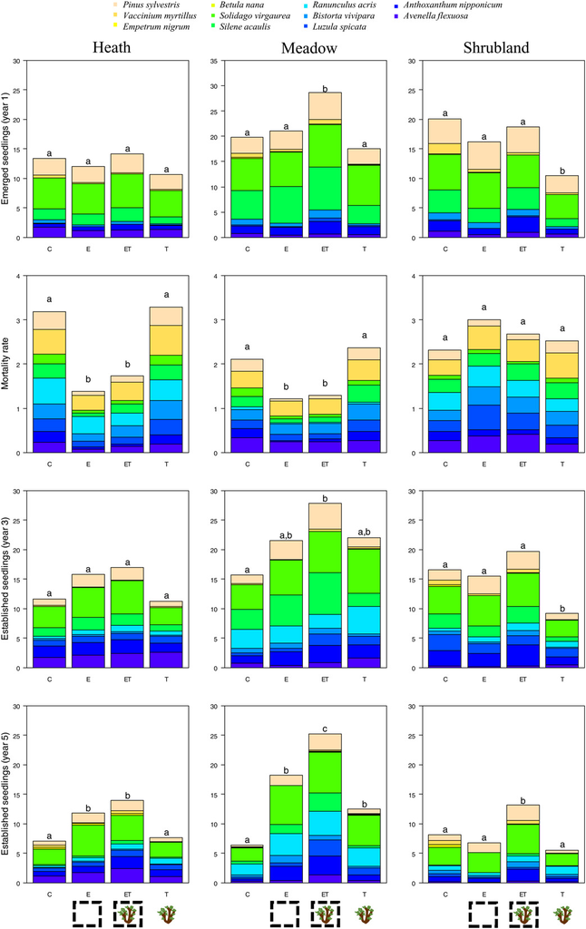

**Figure 3**

Effects of plot‐level experimental treatments (herbivore exclusion, willow introduction) on seedling recruitment in disturbed vegetation (experimental gaps). Treatments are C = control, E = herbivore exclusion, ET = herbivore exclusion + willow introduction, T = willow introduction. Different letters indicate > 95% posterior support. The y‐axis gives the predicted number of seedlings or the summed mortality rate across species (sub‐bars give the predicted number of seedlings or the predicted mortality rate per species).

### Seedling mortality

In intact vegetation, mortality rates were high during the second and third year of the study (mean = 0.57). The largest proportions of variance were explained by the environmental variables representing variation in soil surface temperatures, litter cover and snow depth within and among sites (Table 1, Supporting information), as well as the treatments and their contrasting effects across sites (Table 1; site‐by‐treatment interaction). At the heath and meadow sites, mortality rates tended to be lower in exclosed plots than in open plots (Fig. 2). At the shrubland site, mortality rates were higher in the exclosed, non‐encroached plots and in the non‐exclosed, encroached plots than in the other plot types. We detected only a limited signal of density‐dependent mortality (Table 1, Supporting information).

Patterns of mortality across treatments in the disturbed plots were broadly similar to those observed in intact vegetation. Mortality rates were markedly lower in all exclosed plots compared to open plots at the heath and meadow sites, but not at the shrubland site (Fig. 3), and mortality was largely independent of seedling density (Table 1, Supporting information).

### Seedling establishment

In the third year of the study, the composition of the established seedling assemblages in intact vegetation differed among sites but were broadly similar across treatments (Fig. 2). More seedlings remained at the heath and meadow sites, with a tendency towards more seedlings in the exclosed plots than in the open plots. At the shrubland site few seedlings remained, especially in the exclosed, non‐encroached plots. These trends remained similar after five years, although the tendency towards greater seedling numbers in exclosed plots at the heath and meadow sites became slightly stronger (Fig. 2).

Compared to the intact vegetation plots, the seedling assemblages of the disturbed plots in the third year of the study tended to be more similar across sites (Table 1, Fig. 3). Overall, a greater number of seedlings tended to occur in exclosed plots than in open plots, especially at the meadow site. This pattern became even stronger after five years, when the seedling assemblages of all exclosed plot types were statistically different from those of the control plots, except the exclosed, non‐encroached plots at the shrubland site (Fig. 3).

When comparing seedling establishment at the heath and meadow sites, two woody (*Pinus sylvestris* and *Empetrum nigrum* ssp. *hermaphroditum*) and one graminoid (*Avenella flexuosa*) species tended to establish more successfully at the heath site, while three herbaceous species (*Bistorta vivipara*, *Ranunculus acris* and *Solidago virgaurea*) tended to establish most successfully at the meadow site (Fig. 4).

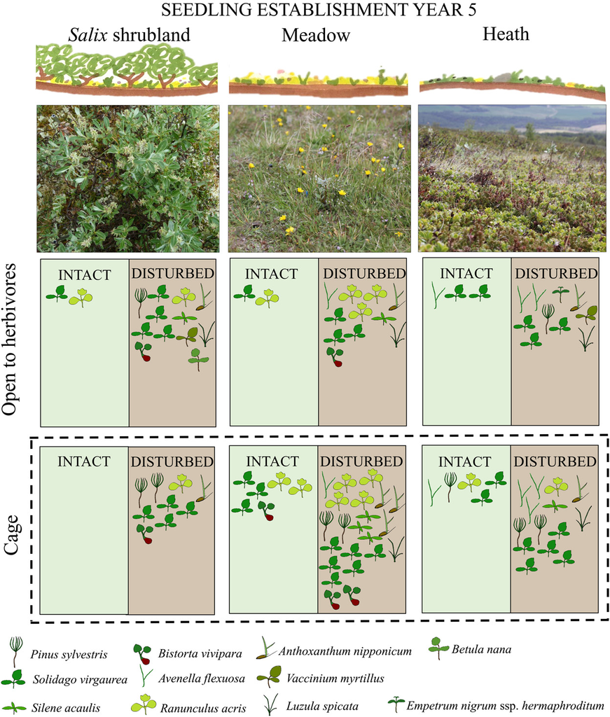

**Figure 4**

Graphical summary of the posterior mean predicted number of established seedlings (rounded to the nearest integer) and the composition of the seedling assemblages five years after sowing in intact and disturbed vegetation, for plots inside cages and plots open to herbivores. Predictions were made for plots without experimental shrub encroachment. In each subplot, 30 seeds were sown of each focal plant species, except for *Pinus sylvestris* with only 10 seeds.

## Discussion

In a five‐year field study, we have demonstrated consistent positive effects of herbivore exclusion on the establishment of vascular‐plant seedlings in both intact and experimentally disturbed alpine vegetation. The effect of herbivory on seedling establishment arose primarily via reduced seedling mortality in plots from which herbivores had been experimentally excluded. In contrast, we detected no consistent effects of experimental shrub encroachment on seedling recruitment. The effect of herbivore exclusion became noticeably stronger over time, suggesting that effects of herbivory on seedling recruitment accumulates over time and may relate to recruitment phases beyond initial emergence. The escalating effects of experimental herbivore exclusion further underlines the importance of long‐term studies for understanding the dynamics of alpine plant communities subject to changes in the biotic and abiotic environment.

### Strong effects of natural vegetation type and cover on seedling recruitment

Seedling emergence was a critical stage during recruitment, particularly in intact vegetation. Reduced recruitment success in intact vegetation, as indicated by stronger vegetation‐removal effects, at the meadow and shrubland sites compared to the heath site may relate to the dense understories characterizing these sites. At the meadow site, dense root systems could lead to intense belowground competition and lower seedling performance (Germino et al. 2002, Loranger et al. 2017), yet the reduced mortality at the meadow suggests that the lack of gaps for emergence is probably the main limitation, as suggested by Gough (2006) for tussock tundra. The competitive effect of aboveground vegetation is more obvious at the shrubland site, where emergence was low and mortality high in intact vegetation. Many studies have tried to link the harshness of the environment to the importance of gaps and microclimate for seedling recruitment. The ‘stress gradient hypothesis' predicts that seedling recruitment under harsh climatic conditions is facilitated by surrounding vegetation through microclimatic buffering, whereas seedling recruitment in more benign microclimates is limited by competitive interactions (Callaway et al. 2002, Brooker et al. 2007, Maestre et al. 2009). Most studies assessing seedling recruitment along assumed stress gradients have suggested that competition is the principal driver, while evidence for facilitative interactions is scarce (Graae et al. 2011, Milbau et al. 2013; but see Venn and Morgan 2009). Our results corroborate this view because we find far more emergent and a tendency for more surviving seedlings in the disturbed plots irrespective of harshness of the microclimate as indicated by vegetation types, although seedlings in disturbed plots may be more vulnerable during extreme weather events than those in more protected microsites (e.g. within vegetation).

### Effects of herbivory on invasibility increase over time

Our herbivore exclusion treatment allowed us to study the impact of large and small mammalian herbivores on seedling recruitment. While we detected only limited effects of herbivore exclusion on first‐year emergence, these effects became apparent when considering seedling survival during the two subsequent years at the heath and meadow sites, but not at the shrubland site. The differential mortality between exclosed and open plots led to differences in the seedling assemblages of these plot types in the third year of the study, and the effects became even clearer in the fifth year (Fig. 2, 3). Although we cannot ascertain the exact causes of mortality, several observations suggest that seedling mortality in open meadow and heath plots results from selective grazing rather than accidental trampling. First, sheep are important and abundant large herbivores in the study area and are generally thought to graze selectively. Indeed, three species known to be attractive to sheep (*A. flexuosa*, *A. nipponicum* and *S. virgaurea*; Rekdal 2001) recruited more successfully within exclosures. Second, the positive effect of herbivore exclusion on seedling survival was stronger in disturbed plots, perhaps because seedlings on bare soil are easier to detect and thus more likely to be eaten. Because the experimental seeds were sown shortly after the exclosures were established, and changes in alpine vegetation are slow (Billings 1987, Morris and Doak 1998, Körner 2003), we could not rule out any positive impacts of herbivores on recruitment through competitive release from the standing vegetation, as Eskelinen and Virtanen (2005) have suggested for snowbed vegetation. Nevertheless, these results demonstrate a strong effect of herbivores on seedling recruitment, and that these effects become increasingly important over time. These findings add to the emerging consensus that herbivores play an important role in buffering environmental‐change‐induced changes to tundra vegetation (Munier et al. 2010, Speed et al. 2012, Kaarlejärvi et al. 2015, 2017, Eskelinen et al. 2016), and are consistent with a recent meta‐analysis suggesting that effects of global‐change experiments such as ours escalate over time (Komatsu et al. 2019).

Because our herbivore exclosures excluded both large (sheep, reindeer) and small (rodents) herbivores, we cannot directly separate their effects. Previous work in tundra systems suggest that ungulates and rodents may have complementary effects (Ravolainen et al. 2014), and that rodents may sometimes be the key herbivores affecting the vegetation dynamics in these systems (Olofsson et al. 2004, Nystuen et al. 2014). However, the weaker herbivory effect at the shrubland site, where we expected rodents to be of greater importance than sheep, suggests that this is not necessarily a general pattern. These findings must also be interpreted in light of the reduced frequency of high rodent peaks in the study area, which may lead to dramatic changes in recruitment patterns (Nystuen et al. 2014).

### Weak effects of experimental shrub encroachment

We detected no consistent positive or negative effect of willow introduction on seedling recruitment. Although recruitment patterns in plots receiving willow transplants differed from corresponding control plots in a few cases (Fig. 2, 3), these apparent effects were largely idiosyncratic and hard to explain as the outcome of willow‐seedling interactions. For example, the apparent negative effect of willow introduction on seedling emergence in disturbed subplots at the shrubland site (where any effect of willow introduction at all is surprising) weakened over time, so that the willow‐introduction plots became more similar to the controls (Fig. 3). It is also possible that the observed effect of willow introduction arose from disturbance associated with the planting of willows, rather than any effect of the introduced willows per se. We therefore conclude that the effect of willow introduction over the first five years of the experiment is at best weak and hard to predict. We suspect that the lack of detectable effects is related to investment in belowground biomass and slow above‐ground growth of the introduced willows, as also indicated by limited effects of the willow introduction on plot‐level carbon cycling (Sørensen et al. 2018b) and pine seedling performance (Marsman et al. 2020) in parallel studies. We expect accelerated aboveground growth of the transplanted willows after 6–7 growing seasons (Rytter 2001, Hagen and Skrindo 2010).

### Species‐specific recruitment responses

Our focus on the overall effects of the experimental treatments implicitly treats our focal species as a ‘random effect', thus assuming that they constitute a representative sample of alpine plants. However, a few notes on species‐specific effects are warranted. The forbs *Solidago virgaurea* and *Ranunculus acris* emerged as the most successful species in terms of establishment, and especially *R. acris* did best at its ‘home site' (meadow). The cushion plant *Silene acaulis* is a pioneer species of harsh environments (Molenda et al. 2012), and emerged at a high rate during the first year of the experiment, but also suffered from high mortality and was rare in most plots at the end of the experiment, perhaps due to low competitive ability. Two species (*Luzula spicata*, *Vaccinium myrtillus*) recruited only where the vegetation was removed, which could reflect high light requirements for seed germination and/or seedling survival in these species. The graminoid *Avenella flexuosa* established more successfully in both intact and vegetation‐removal plots at the more drought‐prone heath compared to meadow and shrubland vegetation, possibly benefitting from plasticity in seedling root growth (i.e. producing deeper and simpler roots in response to drought; Hanslin et al. 2019). These examples illustrate how the identity of the recruiting species as well as the properties of the receiving vegetation is important for recruitment success, and that certain species may not recruit at all in the absence of disturbances.

### Conclusions and implications for vegetation dynamics

Our results strongly suggest that herbivores play an important role in seedling recruitment in alpine plant communities. This provides a clear example of an indirect effect of changes in climate and land‐use on biotic community dynamics, because changes in herbivore communities are directly related to climate (e.g. rodent population dynamics) and human land‐use (e.g. summer sheep grazing versus wild ungulate harvesting regimes). One open question is how recruitment patterns such as those described in this study translate into long‐term vegetation dynamics. For example, despite substantial recruitment, herbaceous plants are rare in alpine heath vegetation, suggesting strong biotic or abiotic filters acting at a later stage. This study demonstrates such filtering effects on the establishment phases following germination and that herbivores are important drivers also of seedling mortality and establishment.

### Data accessibility statement

Data available from the Dryad Digital Repository:<http://dx.doi.org/10.5061/dryad.931zcrjjj> (Opedal et al. 2021).

*Acknowledgements* – We are grateful to the ECOSHRUB field teams that have contributed to data collection, including K. Sundsdal, M. Skar Knutsen, F. Marsman, J. Foest, R. E. Kapás, B. Blonder, K. Helsen, L. Uphus, N. Stam, S. Flo, E. R. Åsheim and J. Mynors. We also thank the Norwegian Forest Seed Center for donating pine seeds, and Kongsvoll Biological Station and Norsk Villreinsenter Nord for logistical support during field campaigns.

### Author contributions

**Øystein H. Opedal**: Conceptualization (equal); Data curation (supporting); Formal analysis (lead); Investigation (equal); Methodology (equal); Visualization (equal); Writing – original draft (lead); Writing – review and editing (lead). **Kristin O. Nystuen**: Conceptualization (equal); Data curation (lead); Formal analysis (supporting); Funding acquisition (equal); Investigation (equal); Methodology (equal); Project administration (lead); Visualization (equal); Writing – original draft (supporting); Writing – review and editing (supporting). **Dagmar Hagen**: Investigation (supporting); Methodology (supporting); Resources (supporting); Writing – original draft (supporting); Writing – review and editing (supporting). **Håkon Holien**: Conceptualization (equal); Investigation (equal); Methodology (equal); Writing – original draft (supporting). **Mia V. Sørensen**: Data curation (supporting); Methodology (supporting); Writing – original draft (supporting). **Simone I. Lang**: Investigation (supporting); Writing – original draft (supporting); Writing – review and editing (supporting). **Sigrid Lindmo**: Investigation (supporting); Project administration (supporting). **G. Richard Strimbeck**: Conceptualization (supporting); Investigation (supporting); Project administration (supporting); Writing – original draft (supporting). **Bente J. Graae**: Conceptualization (equal); Funding acquisition (equal); Investigation (equal); Methodology (equal); Project administration (equal); Resources (equal); Writing – original draft (supporting); Writing – review and editing (supporting).

[Volume39, Issue2](https://onlinelibrary.wiley.com/toc/17561051/2021/39/2)

February 2021

### Details

- © 2021 The Authors. Nordic Journal of Botany published by John Wiley & Sons Ltd on behalf of Nordic Society Oikos

  This is an open access article under the terms of the [Creative Commons Attribution](http://creativecommons.org/licenses/by/3.0/) License, which permits use, distribution and reproduction in any medium, provided the original work is properly cited.

### Keywords

  - [climate change](https://onlinelibrary.wiley.com/action/doSearch?field1=Keyword&text1=climate%20change)
  - herbivory
  - [plant–animal interactions](https://onlinelibrary.wiley.com/action/doSearch?field1=Keyword&text1=plant%E2%80%93animal%20interactions)
  - [seedling recruitment](https://onlinelibrary.wiley.com/action/doSearch?field1=Keyword&text1=seedling%20recruitment)
  - [shrub encroachment](https://onlinelibrary.wiley.com/action/doSearch?field1=Keyword&text1=shrub%20encroachment)
  - [species interactions](https://onlinelibrary.wiley.com/action/doSearch?field1=Keyword&text1=species%20interactions)
  - [vegetation dynamics](https://onlinelibrary.wiley.com/action/doSearch?field1=Keyword&text1=vegetation%20dynamics)

### Publication History

  - Issue Online: 16 February 2021
  - Version of Record online: 16 February 2021
  - Manuscript accepted: 08 January 2021